# Organización y limpieza de datos

Sesión 2

Luis F. Gomez L.

luis.gomezl@unimilitar.edu.co

Facultad de Estudios a Distancia

2026-11-03

# Preliminares

- Verificar:
  - ¿La carpeta `data` fue creada?
  - ¿El archivo `poblacion_col_2018_2070_largo.rds` fue incluido en `data`?
- Generar carpetas:
  - `018_separar-unir-caracteres-cols-en-r`
    - Crear archivo `001_separar-unir-caracteres-cols.R`

# Separación y unión de caracteres en columnas

## Separar caracteres en columnas

- En datos no ordenados es común encontrar **múltiples variables combinadas dentro de una sola columna** (p. ej. códigos como `m_014` o `f_1524`).
- Para asegurar que **cada variable conforme su propia columna**, el paquete `tidyr` proporciona la familia de funciones `separate_wider_*()` (Wickham 2023, cap. 5).
- Existen 3 alternativas especializadas según el criterio de división:
  1. **`separate_wider_delim()`**: separa columnas a partir de un **delimitador o carácter fijo** (guion bajo `_`, coma `,`, guion `-`, etc.).
  2. **`separate_wider_position()`**: separa basándose en **anchos o posiciones numéricas fijas** de caracteres (ideal para archivos de ancho fijo).
  3. **`separate_wider_regex()`**: separa mediante **patrones de expresiones regulares** (en inglés **regex**), ofreciendo máxima flexibilidad ante estructuras complejas.

## Separar caracteres en columnas

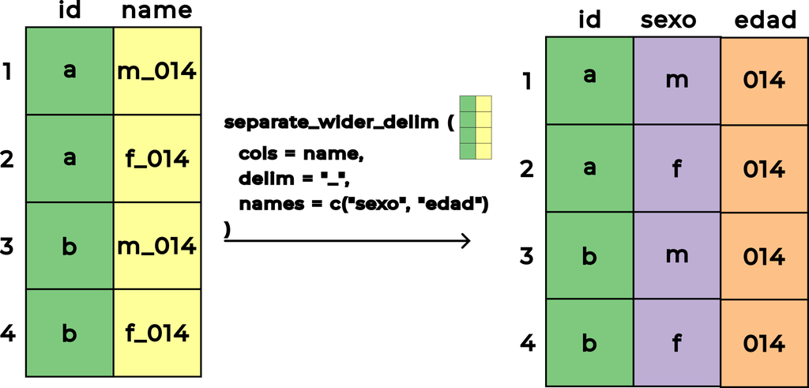

Figura 1: Representación gráfica de la función `separate_wider_delim()`

La columna compuesta `name` (con valores como `m_014` y `f_014`) se divide a partir del delimitador `_` en dos columnas rectangulares independientes: `sexo` y `edad`.

## Unir múltiples columnas mediante concatenación de caracteres

- La función `unite()` de `tidyr` realiza la **operación inversa** a la familia `separate_wider_*()`.
- Toma dos o más columnas y las combina o concatena en una sola columna de caracteres uniendo sus valores mediante un delimitador común.
- Parámetros principales de `unite()`:
  - **`data`**: la tibble sobre la cual se aplicará la transformación.
  - **`col`**: el nombre de la nueva columna resultante.
  - **`...`**: las columnas que se desean unir (admite nombres directos, rangos con `:` o selectores auxiliares).
  - **`sep`**: separador insertado entre los valores unidos (por defecto guion bajo `_`).
  - **`remove`**: valor lógico (`TRUE` por defecto) para eliminar las columnas originales.
  - **`na.rm`**: valor lógico (`FALSE` por defecto) para omitir valores `NA`.

## Unir múltiples columnas mediante concatenación de caracteres

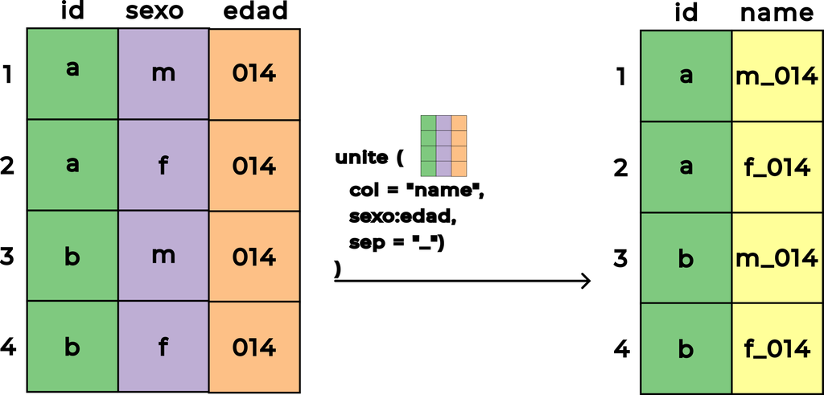

Figura 2: Representación gráfica de la función `unite()`

Dos columnas independientes (`sexo` y `edad`) se fusionan en una única variable compuesta (`name`) mediante el delimitador especificado (`sep = "_"`).

# Caso de estudio: separar caracteres en columnas, transformar y preparar datos para generar pirámides poblacionales de Colombia

## Caso de estudio

- **Contexto**: en la sesión anterior transformamos las proyecciones poblacionales del DANE (2018–2070) a formato largo en `poblacion_col_2018_2070_largo.rds`.
- **Objetivo**: completar el procesamiento de los datos en 3 etapas sucesivas:
  1. **Separar**: dividir la columna compuesta `genero_edad` en `genero` y `edad` mediante `separate_wider_delim()`.
  2. **Transformar**: asociar los tipos correctos (`as.integer()`) y calcular la participación porcentual (`poblacion / total`) con `mutate()`.
  3. **Preparar**: discretizar edades en cohortes quinquenales con `cut()` y consolidar totales y porcentajes con `group_by()` y `summarize()`.

## Importar datos en formato largo

```r
# Cargar paquetes ----
library(tidyverse)

# Importar datos ----
poblacion_col_2018_2070_largo <- read_rds(
  file = "data/poblacion_col_2018_2070_largo.rds"
)

poblacion_col_2018_2070_largo
```

```
# A tibble: 10,706 × 4
     ano    total genero_edad    poblacion
   <dbl>    <dbl> <chr>              <dbl>
 1  2018 48258494 hombres_0_anos    379611
 2  2018 48258494 hombres_1_ano     384392
 3  2018 48258494 hombres_2_anos    389812
 4  2018 48258494 hombres_3_anos    395361
 5  2018 48258494 hombres_4_anos    400077
 6  2018 48258494 hombres_5_anos    405013
 7  2018 48258494 hombres_6_anos    410040
 8  2018 48258494 hombres_7_anos    415839
 9  2018 48258494 hombres_8_anos    421676
10  2018 48258494 hombres_9_anos    427467
# ℹ 10,696 more rows
```

## Separar caracteres en columnas

- En la columna `genero_edad`, cada celda contiene etiquetas compuestas como `"hombres_0_anos"` o `"mujeres_100_anos_y_mas"`.
- El primer segmento define el género (`"hombres"` o `"mujeres"`), el segundo la edad numérica (`0`, …, `100`), y el resto corresponde a sufijos redundantes (`"anos"`, `"ano"`, `"anos_y_mas"`).
- Empleamos `separate_wider_delim()` con:
  - `cols = genero_edad`
  - `delim = "_"`
  - `names = c("genero", "edad")`
  - **`too_many = "drop"`**: conserva los 2 primeros elementos extraídos y descarta los fragmentos sobrantes posteriores.

## Separar caracteres en columnas

```r
# Separar ----
poblacion_col_2018_2070_separar <- poblacion_col_2018_2070_largo |>
  separate_wider_delim(
    cols = genero_edad,
    delim = "_",
    names = c("genero", "edad"),
    too_many = "drop"
  )

poblacion_col_2018_2070_separar
```

```
# A tibble: 10,706 × 5
     ano    total genero  edad  poblacion
   <dbl>    <dbl> <chr>   <chr>     <dbl>
 1  2018 48258494 hombres 0        379611
 2  2018 48258494 hombres 1        384392
 3  2018 48258494 hombres 2        389812
 4  2018 48258494 hombres 3        395361
 5  2018 48258494 hombres 4        400077
 6  2018 48258494 hombres 5        405013
 7  2018 48258494 hombres 6        410040
 8  2018 48258494 hombres 7        415839
 9  2018 48258494 hombres 8        421676
10  2018 48258494 hombres 9        427467
# ℹ 10,696 more rows
```

## Transformar variables

- Tras la separación, la columna `edad` es de tipo carácter (`<chr>`) y la columna `ano` requiere confirmarse como entero.
- Para comparar adecuadamente las pirámides demográficas entre periodos con tamaños absolutos diferentes, se calcula la **proporción porcentual**
- Con `mutate()`:
  - `ano = as.integer(ano)`
  - `edad = as.integer(edad)`
  - `poblacion_pct = poblacion / total` (medida estandarizada en $[0, 1]$).

## Transformar variables

```r
# Transformar ----
poblacion_col_2018_2070_transformar <- poblacion_col_2018_2070_separar |>
  mutate(
    ano = as.integer(ano),
    edad = as.integer(edad),
    poblacion_pct = poblacion / total
  )

poblacion_col_2018_2070_transformar
```

```
# A tibble: 10,706 × 6
     ano    total genero   edad poblacion poblacion_pct
   <int>    <dbl> <chr>   <int>     <dbl>         <dbl>
 1  2018 48258494 hombres     0    379611       0.00787
 2  2018 48258494 hombres     1    384392       0.00797
 3  2018 48258494 hombres     2    389812       0.00808
 4  2018 48258494 hombres     3    395361       0.00819
 5  2018 48258494 hombres     4    400077       0.00829
 6  2018 48258494 hombres     5    405013       0.00839
 7  2018 48258494 hombres     6    410040       0.00850
 8  2018 48258494 hombres     7    415839       0.00862
 9  2018 48258494 hombres     8    421676       0.00874
10  2018 48258494 hombres     9    427467       0.00886
# ℹ 10,696 more rows
```

## Preparar datos para visualizarlos

- En demografía, las edades se agrupan en **cohortes quinquenales**: `0-4`, `5-9`, …, `80-84` y `85+`.
- La función `cut()` discretiza la variable `edad`:
  - `breaks = c(seq.int(0, 85, 5), "Inf")`: cortes cada 5 años hasta infinito.
  - `labels`: secuencia generada con `str_c(seq(0, 80, 5), seq(4, 85, 5), sep = "-")` agregando `"85+"`.
  - `right = FALSE`: intervalos $[0, 5)$, abarcando de 0 a 4 años cumplidos.
- Posteriormente, con `group_by(ano, genero, rango_edad)` y `summarize()`, sumamos la población absoluta y su porcentaje relativo.

## Preparar datos para visualizarlos

```r
# Preparar datos ----
poblacion_col_2018_2070_preparar <- poblacion_col_2018_2070_transformar |>
  group_by(ano, genero) |>
  mutate(
    rango_edad = cut(
      edad,
      breaks = c(seq.int(0, 85, 5), "Inf"),
      labels = c(
        str_c(
          seq(0, 80, 5),
          seq(4, 85, 5),
          sep = "-"
        ),
        "85+"
      ),
      right = FALSE
    )
  ) |>
  ungroup() |>
  group_by(ano, genero, rango_edad) |>
  summarize(
    poblacion = sum(poblacion),
    poblacion_pct = sum(poblacion_pct),
    .groups = "drop"
  )

poblacion_col_2018_2070_preparar
```

```
# A tibble: 1,908 × 5
     ano genero  rango_edad poblacion poblacion_pct
   <int> <chr>   <fct>          <dbl>         <dbl>
 1  2018 hombres 0-4          1949253        0.0404
 2  2018 hombres 5-9          2080035        0.0431
 3  2018 hombres 10-14        2192498        0.0454
 4  2018 hombres 15-19        2158466        0.0447
 5  2018 hombres 20-24        2069100        0.0429
 6  2018 hombres 25-29        1902635        0.0394
 7  2018 hombres 30-34        1698592        0.0352
 8  2018 hombres 35-39        1595799        0.0331
 9  2018 hombres 40-44        1397601        0.0290
10  2018 hombres 45-49        1320949        0.0274
# ℹ 1,898 more rows
```

# Caso de estudio: visualizar datos a través de pirámides poblacionales de Colombia

## Propósito de la visualización

- El ordenamiento y la preparación de datos tienen como fin responder a preguntas analíticas y comunicar patrones claros.
- A través de las **pirámides poblacionales** analizaremos la dinámica demográfica de Colombia en el periodo 2018–2070:
  - La evolución de las cohortes generacionales a lo largo del tiempo.
  - La contracción de la base de la pirámide asociada a la disminución en la tasa de natalidad.
  - El progresivo proceso de envejecimiento poblacional y la ampliación de la cúspide etaria.

## Selección de años de interés

- El horizonte de proyecciones comprende **53 periodos anuales** (2018 a 2070).
- Graficar todos los años saturaría la visualización, por lo que seleccionamos 4 hitos representativos calculados dinámicamente con variables auxiliares:
  1. `pull(ano)`: extrae el vector numérico de años.
  2. `min()` y `max()`: halla el inicio ($2018$) y el fin ($2070$).
  3. `seq.int(ano_min, ano_max, length.out = 4)`: calcula 4 momentos equidistantes: **2018, 2035, 2052 y 2070**.
  4. `filter(ano %in% filtrar_ano)`: filtra la tibble únicamente a esos 4 años.

## Selección de años de interés

```r
# Filtrar ----
## Variables auxiliares ----
ano <- poblacion_col_2018_2070_preparar |>
  pull(ano)

ano_min <- min(ano)
ano_max <- max(ano)

filtrar_ano <- seq.int(
  from = ano_min,
  to = ano_max,
  length.out = 4
) |>
  as.integer()

poblacion_col_filtrar <- poblacion_col_2018_2070_preparar |>
  filter(
    ano %in% filtrar_ano
  )

poblacion_col_filtrar
```

```
# A tibble: 144 × 5
     ano genero  rango_edad poblacion poblacion_pct
   <int> <chr>   <fct>          <dbl>         <dbl>
 1  2018 hombres 0-4          1949253        0.0404
 2  2018 hombres 5-9          2080035        0.0431
 3  2018 hombres 10-14        2192498        0.0454
 4  2018 hombres 15-19        2158466        0.0447
 5  2018 hombres 20-24        2069100        0.0429
 6  2018 hombres 25-29        1902635        0.0394
 7  2018 hombres 30-34        1698592        0.0352
 8  2018 hombres 35-39        1595799        0.0331
 9  2018 hombres 40-44        1397601        0.0290
10  2018 hombres 45-49        1320949        0.0274
# ℹ 134 more rows
```

## Creación de pirámides poblacionales

Para construir la visualización utilizaremos el paquete `ggplot2` y la **gramática de gráficos en capas**, abordando secuencialmente:

1. **Datos, mapeo y capas**: geometría `geom_col()` y simetría bilateral con `ifelse()`.
2. **Facetas**: división en 4 paneles temporales con `facet_wrap()`.
3. **Escalas**: ajuste de marcas numéricas, formato porcentual positivo sin signo negativo y capitalización de leyendas.
4. **Tema**: reubicación estratégica de la leyenda para optimizar el espacio horizontal.

## Datos, mapeo y capas

### Mapeo inicial apilado

```r
# Cargar paquetes ----
library(scales)

# Visualización ----
poblacion_col_filtrar |>
  ggplot(
    aes(
      x = poblacion_pct,
      y = rango_edad
    )
  ) +
  geom_col(
    aes(fill = genero)
  )
```

Ambos géneros parten desde $0$ y se extienden a la derecha (`position = "stack"`), sin reflejar la bilateralidad característica de una pirámide.

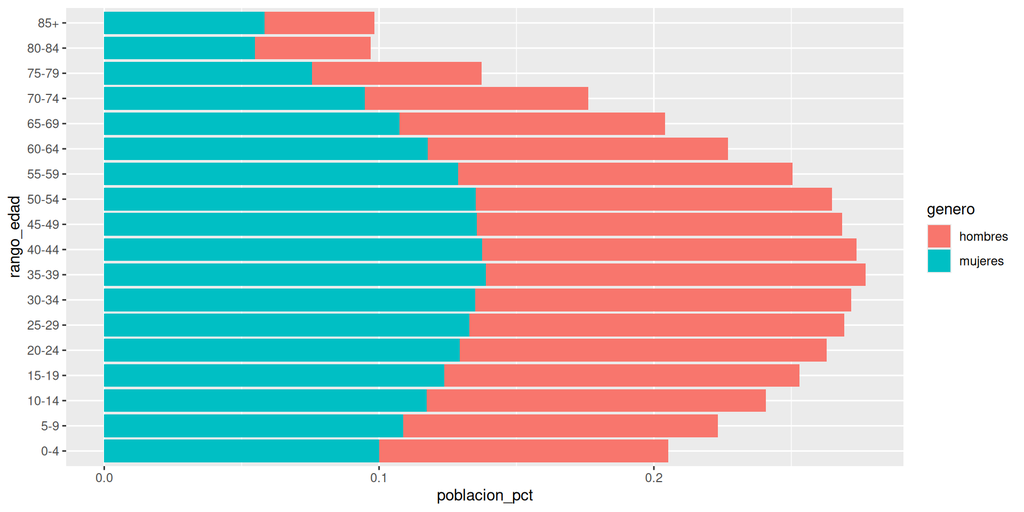

## Datos, mapeo y capas

### Simetría bilateral con `ifelse()`

```r
poblacion_col_filtrar |>
  ggplot(
    aes(
      x = ifelse(
        test = genero == "hombres",
        yes = poblacion_pct,
        no = -poblacion_pct
      ),
      y = rango_edad
    )
  ) +
  geom_col(
    aes(fill = genero),
    color = "black"
  )
```

Invertir el signo de las mujeres (`-poblacion_pct`) proyecta sus barras a la izquierda del origen $0$, generando la silueta bilateral.

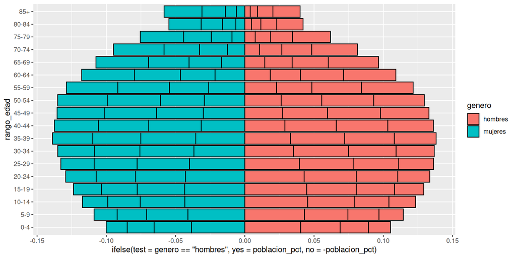

## Facetas

### División por año con `facet_wrap()`

```r
poblacion_col_filtrar |>
  ggplot(
    aes(
      x = ifelse(
        test = genero == "hombres",
        yes = poblacion_pct,
        no = -poblacion_pct
      ),
      y = rango_edad
    )
  ) +
  geom_col(
    aes(fill = genero),
    color = "black"
  ) +
  facet_wrap(
    facets = vars(ano)
  )
```

`facet_wrap(facets = vars(ano))` crea un panel independiente para cada año (2018, 2035, 2052 y 2070), evitando la superposición de datos.

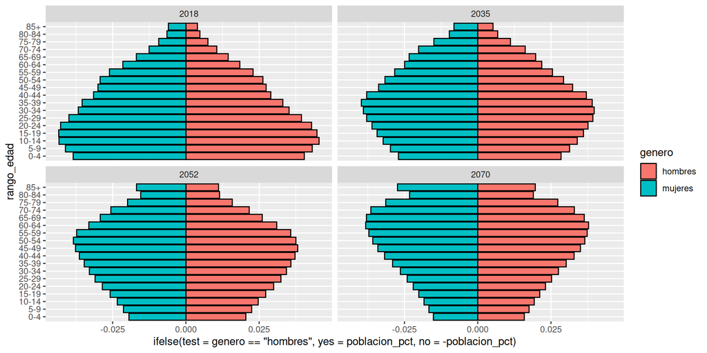

## Escalas

- Aspectos a ajustar en las escalas:
  1. **Valores positivos en porcentaje**: el eje horizontal muestra valores negativos (p. ej. `-0.025`). Definimos marcas con `poblacion_pct_breaks <- seq.int(-0.04, 0.04, 0.01)`.
  2. **Función anónima**: `\(x) label_percent(accuracy = 1)(abs(x))` aplica el valor absoluto `abs()` y formatea en porcentaje entero (`4%`).
  3. **Capitalización de leyendas**: `scale_fill_discrete(labels = str_to_title)` convierte `"hombres"` $\rightarrow$ `"Hombres"` y `"mujeres"` $\rightarrow$ `"Mujeres"`.
  4. **Textos informativos**: con `labs()`, títulos descriptivos, fecha de corte y fuente oficial, suprimiendo etiquetas redundantes en los ejes (`NULL`).

## Escalas

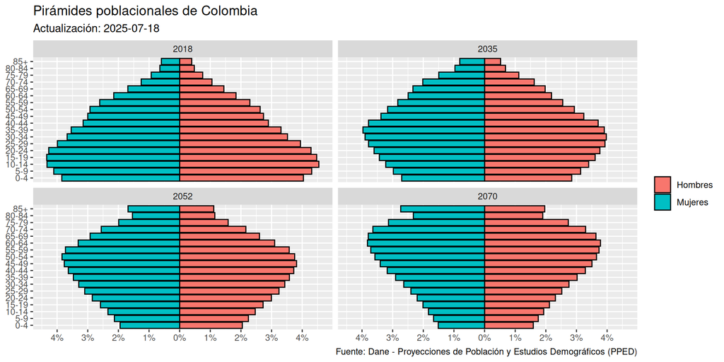

```r
# Variables auxiliares ----
poblacion_pct_breaks <- seq.int(
  from = -0.04,
  to = 0.04,
  by = 0.01
)

actualizacion_fecha <- ymd("2025-07-18")

poblacion_col_filtrar |>
  ggplot(
    aes(
      x = ifelse(
        test = genero == "hombres",
        yes = poblacion_pct,
        no = -poblacion_pct
      ),
      y = rango_edad
    )
  ) +
  geom_col(
    aes(fill = genero),
    color = "black"
  ) +
  facet_wrap(
    facets = vars(ano)
  ) +
  scale_x_continuous(
    breaks = poblacion_pct_breaks,
    labels = \(x) label_percent(accuracy = 1)(abs(x))
  ) +
  scale_fill_discrete(
    labels = str_to_title
  ) +
  labs(
    x = NULL,
    y = NULL,
    fill = NULL,
    title = "Pirámides poblacionales de Colombia",
    subtitle = str_glue("Actualización: {actualizacion_fecha}"),
    caption = "Fuente: Dane - Proyecciones de Población y Estudios Demográficos (PPED)"
  )
```

## Tema

- Por defecto, `ggplot2` sitúa la leyenda en la parte lateral derecha, comprimiendo el espacio horizontal disponible para los paneles facetados.
- Con `theme(legend.position = "bottom")`, trasladamos la leyenda a la parte inferior otorgando máxima amplitud y legibilidad a las barras.
- **Conclusiones demográficas observables**:
  - En **2018**, la pirámide presenta una base más amplia propia de una estructura poblacional relativamente joven.
  - Hacia **2070**, se evidencia una contracción marcada de la base (menor natalidad) y un ensanchamiento superior (envejecimiento poblacional sostenido).

## Tema

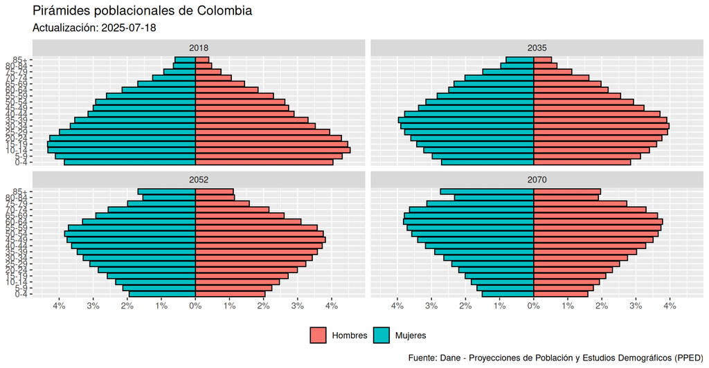

```r
poblacion_col_filtrar |>
  ggplot(
    aes(
      x = ifelse(
        test = genero == "hombres",
        yes = poblacion_pct,
        no = -poblacion_pct
      ),
      y = rango_edad
    )
  ) +
  geom_col(
    aes(fill = genero),
    color = "black"
  ) +
  facet_wrap(
    facets = vars(ano)
  ) +
  scale_x_continuous(
    breaks = poblacion_pct_breaks,
    labels = \(x) label_percent(accuracy = 1)(abs(x))
  ) +
  scale_fill_discrete(
    labels = str_to_title
  ) +
  labs(
    x = NULL,
    y = NULL,
    fill = NULL,
    title = "Pirámides poblacionales de Colombia",
    subtitle = str_glue("Actualización: {actualizacion_fecha}"),
    caption = "Fuente: Dane - Proyecciones de Población y Estudios Demográficos (PPED)"
  ) +
  theme(
    legend.position = "bottom"
  )
```

- **Conclusiones demográficas observables**:
  - En **2018**, la pirámide presenta una base más amplia propia de una estructura poblacional relativamente joven.
  - Hacia **2070**, se evidencia una contracción marcada de la base (menor natalidad) y un ensanchamiento superior (envejecimiento poblacional sostenido).

Gracias

# Referencias

Wickham, Hadley. 2023. *R for Data Science*. 2.ª ed. O’Reilly Media, Incorporated. https://r4ds.hadley.nz/.